# Report on life expectancy

Corinne Riddell

August 25, 2021

# Life expectancy for Black and White men and women in New York between 1969-2013

# Introduction

Life expectancy is one of the core measures used in public health to comment on the well-being of groups of people. Differences in life expectancy by race/ethnicity, for individuals living in the same region can reflect underlying inequalities in policies, access to care, food environments, structural and systemic racism, among other potential causes.

# Research objective (Problem)

The purpose of this short report is to visualize life expectancy among Black and White men and women in New York between 1969 and 2013.

# Plan

Death certificates in the United States include race/ethnicity, age at death, and date of death and capture all deaths of US residents. These data are aggregated by the [CDC’s National Cancer Institute](https://seer.cancer.gov/seerstat/) into the SEER*Stat software. Previously, Riddell et al.<sup>1</sup>, analyzed these data to compute estimated trends in life expectancy for Black and White men and women, for 40 US states between 1969 and 2013. States without enough data were excluded from these analyses.

To carry out this short report, we will use data from Riddell et al. to visualize trends in life expectancy as part of an exploratory data analysis. In particular, we will plot time trends for Black and White men and women in New York.

# Data

Here are the first six rows of these data for New York:

```
## # A tibble: 6 x 8
##   state    stabbrs  year Census_Region Census_Division    LE race  gender
##   <chr>    <chr>   <dbl> <chr>         <chr>           <dbl> <chr> <chr>
## 1 New York NY       1969 Northeast     Mid-Atlantic     74.8 white Women
## 2 New York NY       1969 Northeast     Mid-Atlantic     67.9 white Men
## 3 New York NY       1970 Northeast     Mid-Atlantic     75.0 white Women
## 4 New York NY       1970 Northeast     Mid-Atlantic     68.1 white Men
## 5 New York NY       1971 Northeast     Mid-Atlantic     75.4 white Women
## 6 New York NY       1971 Northeast     Mid-Atlantic     68.4 white Men
```

# Analysis

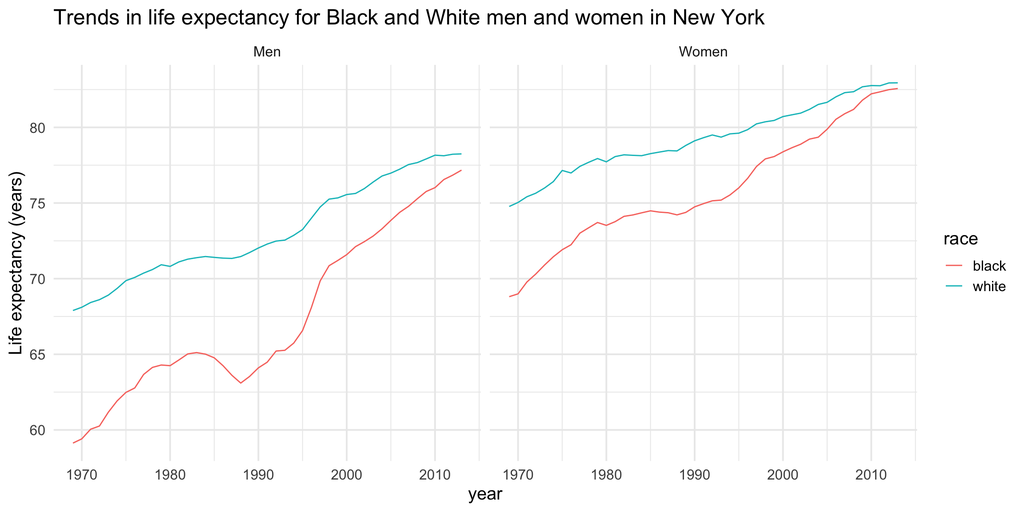

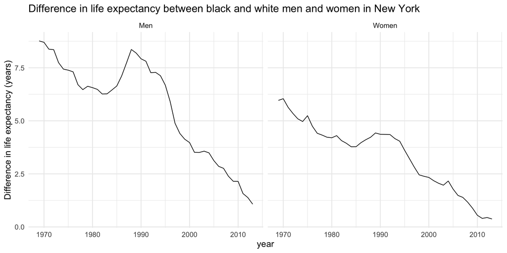

# Conclusion

The difference in life expectancy in 1969 between Blacks and Whites was 8.8 years for men and 6 for women in New York.

By 2013, the difference was 1.1 years for men and 0.4 for women in New York.

# References

1. Riddell CA, Morrison KT, Harper S, Kaufman JS. Trends in the contribution of major causes of death to the black-white life expectancy gap by US state. **Health & Place**. 2018. 52:85-100. doi: 10.1016/j.healthplace.2018.04.003.